# Research Question

My research question, “To what extent can the average PGA Tour golfer’s driving distance be predicted?”, is particularly relevant given the ongoing discussions about increasing driving distances and their impact on the game. The United States Golf Association (USGA) has raised concerns about driving distances exceeding the current regulation of 317 yards, which makes this a forward-looking issue that requires empirical analysis rather than speculation.

This study is necessary because driving distance is a key performance metric in professional golf and has evolved significantly over time due to factors such as:

- Advancements in equipment technology (driver head design, ball aerodynamics)
- Changes in golfer training regimens (increased focus on strength and conditioning)
- Biomechanical efficiency and swing mechanics
- Course design adjustments to account for increasing distances

With regulatory bodies like the USGA and R&A exploring potential rule changes to curb excessive driving distances, it is crucial to establish whether distances are indeed increasing, at what rate, and how soon they might exceed the 317-yard threshold. This research will provide valuable insights for stakeholders, including players, coaches, equipment manufacturers, and golf governing bodies, by using objective data rather than anecdotal evidence.

The PGA Tour serves as the ideal dataset for analyzing historical trends in driving distance. Given the advances in launch monitor technology (TrackMan, GCQuad) and detailed shot-tracking systems (ShotLink), we now have access to high-quality data spanning decades. By leveraging time series analysis and predictive modeling techniques, we can assess whether the increasing trend in driving distance is sustainable or if it is plateauing due to physical, technological, or regulatory constraints.

To systematically evaluate the predictability of driving distance, we define the following hypotheses:

- Hypothesis: The average driving distance can be predicted with 90% accuracy.
- Null Hypothesis (H₀): The average driving distance cannot be predicted with 90% accuracy.
- Alternative Hypothesis (H₁): The average driving distance can be predicted with an accuracy significantly greater than 90%.

Using time series forecasting methods such as Holt's,we can determine whether current trends suggest that driving distances will exceed 317 yards in the near future. If the alternative hypothesis is supported, this would indicate that driving distance is highly predictable and that governing bodies may need to take proactive steps to regulate equipment, course length, or other contributing factors.

If this research confirms that driving distances are increasing at a predictable rate, it could reinforce the USGA’s justification for equipment rollbacks or rule changes to maintain the integrity of golf course design. Conversely, if the findings show that distance gains are slowing, it could challenge the necessity of such interventions. This study will provide quantifiable insights into the future of professional golf performance, ensuring that any potential regulatory changes are data-driven rather than reactionary.

# Relevant Data Collected:

The dataset extracted from PGA TOUR.com includes historical performance statistics of professional golfers from 1987 to 2023. The collected data includes.

# Data-Gathering Methodology:

This dataset was collected using web scraping from PGA TOUR’s official statistics pages. The approach involved:

- Accessing publicly available statistics on Driving Distance, Par 4 Average, and Par 5 Average from 1987 to 2023.
- Automating data extraction using BeautifulSoup libraries to handle rendered content.
- Structuring the data into a single DataFrame to merge statistics across different years and players.

# Advantage of This Data-Gathering Methodology:

Comprehensive Historical Data:

- Automating the collection process allowed for the extraction of large-scale, structured data from multiple seasons efficiently.
- The method provided reliable access to PGA TOUR statistics, ensuring the dataset is accurate and historically complete.
- This dataset can be used for trend analysis, predictive modeling, and player performance comparisons.

# Disadvantage of This Data-Gathering Methodology:

Website Structure Limitations:

- The PGA TOUR website started using JavaScript to load data dynamically, making traditional static web scraping (with BeautifulSoup) ineffective after 2023.
- Manual downloads(2024-2025)from the PGA TOUR website.

# Challenges Encountered and How They Were Overcome:

- The website’s structure did not allow direct URL modification to access different years, requiring manual year selection.
- Manually downloaded driving stats, par 4, and par 5 stats from top tournaments for years 2024 - 2025.
- Some years were missing data due to website limitations or player inactivity.
- Data cleaning techniques were applied to remove incomplete or erroneous records while maintaining consistency.

# Conclusion:

This dataset provides a rich historical record of PGA TOUR player performance. The web scraping approach ensured that the data was collected efficiently despite challenges related to website structure. The insights derived from this dataset can be used for predictive modeling, trend analysis, and player evaluation in professional golf.

```python
# Import 'final.py' to expedite and maintain cleanliness
import final as f
import warnings
warnings.filterwarnings("ignore")
```

```python
# From the 'final.py' file...
# Get the main stats prepared dataframe
df = f.acquire_data()
df.head()
```

|  | player | year | par_4_avg | par_5_avg | drive_avg |
| --- | --- | --- | --- | --- | --- |
| 0 | Payne Stewart | 1987 | 3.98 | 4.65 | 269.9 |
| 1 | Dan Pohl | 1987 | 3.98 | 4.63 | 273.0 |
| 2 | Lanny Wadkins | 1987 | 3.97 | 4.74 | 253.3 |
| 3 | Paul Azinger | 1987 | 3.98 | 4.63 | 269.5 |
| 4 | David Frost | 1987 | 3.98 | 4.64 | 259.2 |

```python
df.shape
```

```
(7048, 5)
```

```python
# Additional data for 2024 and 2025
output_path = "Final_Cleaned_Merged_Stats.csv"
df2 = f.clean_and_merge_final_stats("Stats_Merged.csv", "Par5stats_Merged.csv", "Par4stats_Merged.csv", output_path)
df2.head()
```

|  | player | year | par_4_avg | par_5_avg | drive_avg |
| --- | --- | --- | --- | --- | --- |
| 0 | Aaron Baddeley | 2024 | 4.06 | 4.67 | 283.4 |
| 1 | Aaron Baddeley | 2025 | 4.05 | 4.68 | 292.6 |
| 2 | Aaron Rai | 2024 | 3.92 | 4.33 | 293.8 |
| 3 | Aaron Rai | 2025 | 3.97 | 4.54 | 281.9 |
| 4 | Adam Hadwin | 2024 | 3.91 | 4.53 | 297.6 |

```python
df2.shape
```

```
(476, 5)
```

```python
# Merged 2024 & 2025 data onto the main dataset(1987-2023)
output_path = "Merged_PGA_Stats_AvgFilled.csv"
df_merged = f.merge_datasets_fill_avg("Final_Cleaned_Merged_Stats.csv", "pga_scoring_and_drive.csv", output_path)
df_merged.head()
```

|  | player | year | par_4_avg | par_5_avg | drive_avg |
| --- | --- | --- | --- | --- | --- |
| 0 | Aaron Baddeley | 2003 | 4.06 | 4.54 | 287.9 |
| 1 | Aaron Baddeley | 2004 | 4.15 | 4.69 | 288.0 |
| 2 | Aaron Baddeley | 2005 | 4.07 | 4.65 | 291.4 |
| 3 | Aaron Baddeley | 2006 | 4.10 | 4.64 | 288.3 |
| 4 | Aaron Baddeley | 2007 | 4.08 | 4.56 | 291.9 |

```python
df_merged.isnull().values.any()
```

```
False
```

```python
df_merged.shape
```

```
(7524, 5)
```

# Data Extraction and Preparation

Data Extraction: The data extraction process involved obtaining multiple CSV files that contained golf player statistics, scoring data, and driving performance. The datasets included:

- Final_Cleaned_Merged_Stats.csv (processed player statistics)
- pga_scoring_and_drive.csv (additional scoring and driving stats)

Tools & Techniques:

- Python & Pandas: Used to load CSV files into Pandas DataFrames.
- read_csv() function: Extracted structured data efficiently.
- File download directly from PGA TOUR website.

Advantages & Disadvantages

- Pandas allows quick data extraction with built-in methods for handling large datasets.
- If data size is extremely large, Pandas can consume high memory and may require chunk processing.

# Data Cleaning & Preparation

Merging Data:

- The datasets were merged on common columns (player and year) using an outer join to retain all records.
- merge() function in Pandas was used to combine datasets efficiently.

Handling Missig Values:

- Missing numerical values were filled with the column average using fillna(df[col].mean()).
- This ensured meaningful imputation without distorting trends.

Removing Duplicates:

- Duplicate columns were removed after merging using df.loc[:, ~df.columns.duplicated()].

Saving the Cleaned Dataset:

- The cleaned dataset was saved as "Merged_PGA_Stats_AvgFilled.csv" for further analysis.

# Screenshots/Markedown Code/Functions used for cleaning and preparation.

Loading the Data: df1 = pd.read_csv("Final_Cleaned_Merged_Stats.csv") df2 = pd.read_csv("pga_scoring_and_drive.csv")

Merging the Data: df_merged = df1.merge(df2, on=["player", "year"], how="outer")

Handlng Missing Values: for col in df_merged.select_dtypes(include=['number']).columns: df_merged[col].fillna(df_merged[col].mean(), inplace=True)

Removing Duplicates: df_merged = df_merged.loc[:, ~df_merged.columns.duplicated()]

Saving the Data: df_merged.to_csv("Merged_PGA_Stats_AvgFilled.csv", index=False)

def clean_and_merge_final_stats(final_filtered_stats: str, par5stats: str, par4stats: str, output_file: str): """ Cleans, merges, and deduplicates the Final Filtered Merged Stats dataset with Par5stats and Par4stats datasets.

```
Parameters:
final_filtered_stats (str): Path to the Final Filtered Merged Stats dataset.
par5stats (str): Path to the Par5stats dataset.
par4stats (str): Path to the Par4stats dataset.
output_file (str): Path to save the final cleaned and deduplicated dataset.

Returns:
pd.DataFrame: The final merged and cleaned dataset.
"""

# Load datasets
df_final_filtered = pd.read_csv(final_filtered_stats)
df_par5stats = pd.read_csv(par5stats)
df_par4stats = pd.read_csv(par4stats)

# Standardize column names
df_par5stats.rename(columns=lambda x: x.lower().replace("avg", "par_5_avg"), inplace=True)
df_par4stats.rename(columns=lambda x: x.lower().replace("avg", "par_4_avg"), inplace=True)

# Merge datasets on "player" and "year"
df_merged = df_final_filtered.merge(df_par5stats, on=["player", "year"], how="outer")\
                             .merge(df_par4stats, on=["player", "year"], how="outer")



# Fix column naming inconsistencies
for col in df_merged.columns:
    if "par_4" in col.lower():
        df_merged.rename(columns={col: "par_4_avg"}, inplace=True)
    if "par_5" in col.lower():
        df_merged.rename(columns={col: "par_5_avg"}, inplace=True)
    if "drive_avg" in col.lower():
        df_merged.rename(columns={col: "drive_avg"}, inplace=True)

# Remove duplicate columns
df_merged = df_merged.loc[:, ~df_merged.columns.duplicated()]

# Keep only the required columns
columns_to_keep = ["player", "year", "par_4_avg", "par_5_avg", "drive_avg"]
df_cleaned = df_merged[columns_to_keep]

# Remove duplicate rows
df_cleaned.drop_duplicates(inplace=True)


# Fill missing values with column average for numerical columns
for col in df_cleaned.select_dtypes(include=['number']).columns:
    df_cleaned[col].fillna(df_cleaned[col].mean(), inplace=True)

# Save the final cleaned dataset
df_cleaned.to_csv(output_file, index=False)

return df_cleaned
```

def merge_datasets_fill_avg(file1: str, file2: str, output_file: str, merge_columns: list = None): """ Merges two datasets on specified columns, removes duplicates, and fills missing numerical values with column averages.

```
Parameters:
file1 (str): Path to the first dataset.
file2 (str): Path to the second dataset.
output_file (str): Path to save the merged dataset.
merge_columns (list, optional): List of column names to merge on. Defaults to common columns.

Returns:
pd.DataFrame: Merged dataset.
"""

# Load datasets
df1 = pd.read_csv(file1)
df2 = pd.read_csv(file2)

# Identify common columns to merge on if not provided
if merge_columns is None:
    merge_columns = list(set(df1.columns) & set(df2.columns))

# Merge datasets
df_merged = df1.merge(df2, on=merge_columns, how="outer")

# Remove duplicate columns if any exist
df_merged = df_merged.loc[:, ~df_merged.columns.duplicated()]

# Fill missing values with column average for numerical columns
for col in df_merged.select_dtypes(include=['number']).columns:
    df_merged[col].fillna(df_merged[col].mean(), inplace=True)

# Save the merged dataset
df_merged.to_csv(output_file, index=False)

return df_merged
```

# Justification for Tools and Techniques

Tool/Technique:

- Pandas(read_csv()) offers fast and easy CSV extraction and is efficient for structured data. A disadvantage is high memory usage for large files.
- merge()(Outer Join) retains all records from both datasets so no data loss. A disadvantage is this can result in missing values.
- fillna(df[col].mean()) replaces missing values with meaningful averages and maintains statistical inegrity. A disadvantage is outliers can introduce bias
- drop_duplicates() ensures clean, non-redundant data but may require careful inspection of duplicate logic.
- embeded functions within a .py file allows for a clean notebook. A disadvantage is keeping two files updated.

# Analysis

Descriptive Statistics:

- Summarized key metrics like mean, standard deviation, min, and max for drive_avg, par_4_avg, and par_5_avg.
- Average Driving Distance 282.15 yards
- Par 4 Average Score 4.05
- Par 5 Average Score 4.67

```python
stats_summary = f.descriptive_statistics(df_merged, ["drive_avg", "par_4_avg", "par_5_avg"])
print(stats_summary)
```

```
         drive_avg    par_4_avg    par_5_avg
count  7524.000000  7524.000000  7524.000000
mean    282.152760     4.050367     4.678224
std      16.047944     0.047520     0.084680
min     237.900000     3.660000     4.000000
25%     269.100000     4.020000     4.630000
50%     283.900000     4.050000     4.680000
75%     294.500000     4.080000     4.730000
max     328.700000     4.290000     5.030000
```

Correlation Analysis:

- Calculated Pearson correlation to identify relationships between driving distance and scoring averages.
- Created a heatmap to visualize these relationships.

Driving Average vs Par 4 Average:

- Negative correlation (-32) with par_4_avg: Longer drives tend to improve par 4 scores.
- The effect is moderate, suggesting that distance alone is not the only factor affecting Par 4 performance.

Driving Average vs Par 5 Average:

- Stronger negative correlation (-0.55) with par_5_avg: Players with long drives perform even better on Par 5s.
- This makes sense because longer drives allow players to reach greens in fewer strokes, leading to more birdie opportunities.

Par 4 Average vs Par 5 Average:

- Positive correlation(0.58) suggest that players who struggle on Par 4s also tend to struggle on Par 5s.
- This could indicate an overall skill gap where better players excel across both hole types.

Insights for Golf Performance:

- Longer drives are more beneficial on Par 5s than on Par 4s.
- Par 4 and Par 5 scoring are linked. Players with strong all-around scoring ability perform well on both.
- Improving driving distance could help lower scores on Par 5s, but other factors(accuracy, approach shots, putting) are also crucial on Par 4s.

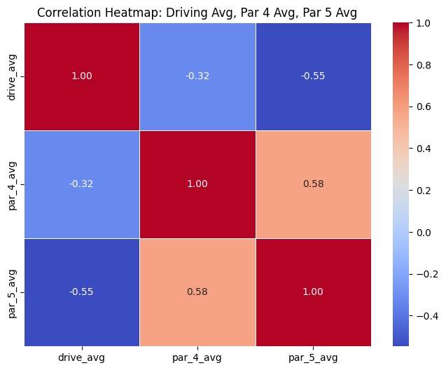

```
           drive_avg  par_4_avg  par_5_avg
drive_avg   1.000000  -0.319465  -0.546232
par_4_avg  -0.319465   1.000000   0.575817
par_5_avg  -0.546232   0.575817   1.000000
```

```python
correlations = f.correlation_analysis(df_merged, ["drive_avg", "par_4_avg", "par_5_avg"])
print(correlations)
```

Clustering Analysis (K-means):

- Used K-means clustering to group players based on their driving average and scoring ability.
- Created scatter plots to show clusters of players performance.

Drive Average vs Par 4 Average (Clustering):

Drive Average vs Par 5 Average(Clustering):

- Cluster 1 (Teal): Players with moderate driving distance and moderate Par 5 scores.
- Cluster 0 (Purple): Players with longer drives and better Par 5 scores.
- Cluster 2 (Yellow): Players with shorter drives and higher Par 5 scores.
- Stronger impact of driving on Par 5s: The clusters are more distinct in this plot, indicating that driving distance plays a more significant role in Par 5 performance.
- Elite cluster (Purple): Cluster 0 players with longer drives consistently achieve lower (better) scores.
- Short hitters (Yellow): Cluster 2 players with shorter drives tend to struggle on Par 5s, likely due to the inability to reach the green in two shots.

Insights for Golf Performance(Clustering):

- Cluster 0 (Purple): Represents elite players who maximize the benefits of longer drives to achieve better scores on both Par 4s and Par 5s.
- Cluster 2 (Yellow): Consists of players who need to improve their driving distance to lower their scores, particularly on Par 5s.
- Cluster 1 (Teal): Includes balanced players who perform moderately well in both driving and scoring but may need targeted improvements to move into the elite group.

```python
df_clustered = f.kmeans_clustering(df_merged, ["drive_avg", "par_4_avg", "par_5_avg"])
print(df_clustered.head())
print(df_clustered.tail())
```

```
           player  year  par_4_avg  par_5_avg  drive_avg  cluster
0  Aaron Baddeley  2003       4.06       4.54      287.9        1
1  Aaron Baddeley  2004       4.15       4.69      288.0        1
2  Aaron Baddeley  2005       4.07       4.65      291.4        0
3  Aaron Baddeley  2006       4.10       4.64      288.3        1
4  Aaron Baddeley  2007       4.08       4.56      291.9        0
             player  year  par_4_avg  par_5_avg  drive_avg  cluster
7519  Ángel Cabrera  2012       4.13       4.66      299.7        0
7520  Ángel Cabrera  2013       4.06       4.75      294.0        0
7521  Ángel Cabrera  2014       4.06       4.67      303.7        0
7522  Ángel Cabrera  2015       4.11       4.60      299.7        0
7523  Ángel Cabrera  2016       4.12       4.81      294.6        0
```

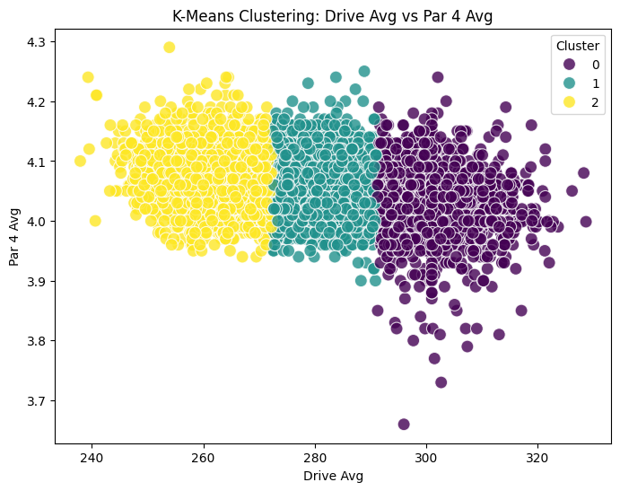

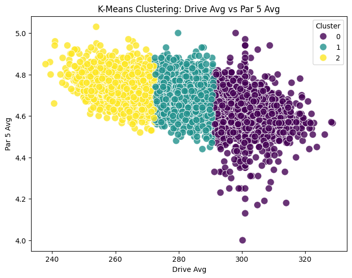

```python
# Apply K-Means clustering
df_clustered = f.kmeans_clustering(df_merged, ["drive_avg", "par_4_avg", "par_5_avg"])

# Plot clusters for Driving Avg vs Par 4 Avg
f.plot_clusters(df_clustered, "drive_avg", "par_4_avg")

# Plot clusters for Driving Avg vs Par 5 Avg
f.plot_clusters(df_clustered, "drive_avg", "par_5_avg")
```

# Modeling

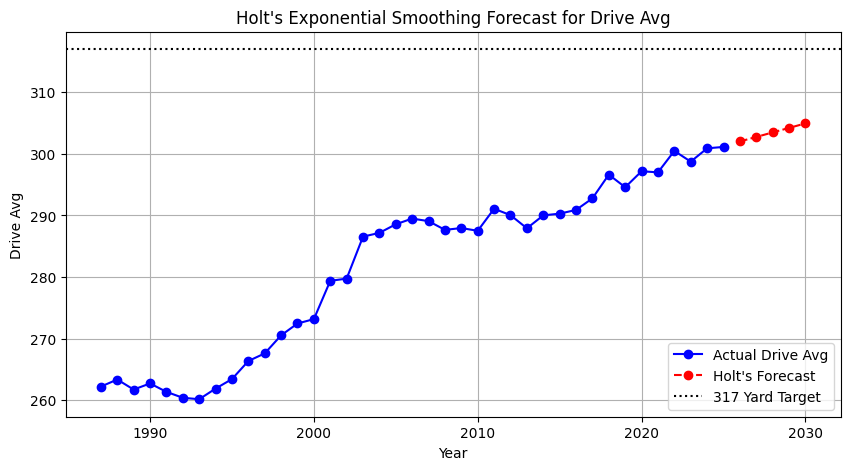

```
Holt's Forecast:
39    302.021149
40    302.754046
41    303.486942
42    304.219839
43    304.952736
dtype: float64
Mean Absolute Error (MAE): 1.6405987813053309
Root Mean Squared Error (RMSE): 2.0067357812409776
R² Score: 0.9787268518917714
```

```python
# Run Holt's model forecast
holt_forecast, mae_holt, rmse_holt, r2_holt = f.holts_model_forecast(df_merged)

# Print results
print("Holt's Forecast:")
print(holt_forecast)
print(f"Mean Absolute Error (MAE): {mae_holt}")
print(f"Root Mean Squared Error (RMSE): {rmse_holt}")
print(f"R² Score: {r2_holt}")
```

```python
#Hypothesis test supporting models significance
t_stat, p_value, decision = f.r2_significance_test(r2_holt, df)

# Print results
print(f"T-Statistic: {t_stat}")
print(f"P-Value: {p_value}")
print(f"Decision: {decision}")
```

```
T-Statistic: 2.2701162735404186
P-Value: 0.014732870175964474
Decision: Reject Null Hypothesis: Holt's model achieves an R² significantly greater than 90%.
```

# Justification for Selected Analysis Techniques

Descriptive Statistics:

- Descriptive statistics are fundamental for understanding the overall distribution, central tendencies, and variability in the data.
- It provides a quick summary of key metrics (e.g., mean, median, standard deviation) for drive_avg, par_4_avg, and par_5_avg, helping identify trends and outliers.
- Advantage: Gives a concise numerical summary of the dataset, allowing for quick insights.
- Disadvantage: It does not explain relationships between variables or reveal underlying patterns.

Correlation Analysis:

- Correlation analysis helps quantify the relationships between variables, specifically: Driving distance (drive_avg) and Par 4/Par 5 scoring averages (par_4_avg, par_5_avg).
- It is crucial to understand whether improving one variable (e.g., driving distance) affects scoring performance.
- Advantage: Reveals relationships: Identifies how strongly variables are associated, useful for prioritizing focus areas.
- Disadvantage: Cannot infer causation: A strong correlation does not imply a causal relationship.

K-Means Clustering:

- K-Means clustering was chosen to segment players into groups based on their performance metrics:
  - Cluster 1: Moderate players.
  - Cluster 0: Elite long hitters.
  - Cluster 2: Shorter hitters with higher scores.
- Advantage: Groups similar data points, making it easier to analyze patterns within groups.
- Disadvantage: K-Means assumes clusters are evenly spaced and circular, which might not always match the data distribution.

Holt's Exponential Smoothing (Times Series Forecasting):

Model Performance:

- Mean Absolute Error (MAE): 1.64 yards. Predictions are, on average, within 1.64 yards of actual values.
- Root Mean Squared Error (RMSE): 2.01 yards. Typical error is around 2.01 yards.
- R² Score: 0.979. Holt’s model explains 97.9% of the variance in driving distance, confirming a strong predictive capability.

Statistical Test for Model Significance:

- T-Statistic: 2.27
- P-Value: 0.0147
- Reject Null Hypothesis. Holt’s model achieves an R² significantly greater than 90%, confirming its statistical reliability for predicting driving distance trends.
- Advantage: Provides a quantitative forecast of future performance, useful for strategy and long-term planning.
- Disadvantage: Exponential Smoothing assumes that past trends continue into the future, which may not always hold due to external factors (e.g., equipment changes, rule modifications, or player conditioning).

# Data Summary and Implications

Descriptive Statistics:

Correlation Analysis:

- Par 5 Average (-0.54): A stronger negative correlation suggests that players who hit longer drives tend to perform better on Par 5 holes, likely due to reaching greens in fewer strokes.
- Par 4 Average (-0.31): The weaker correlation indicates that factors beyond driving distance, such as approach play and putting, significantly affect Par 4 performance.

K-Means Clustering:

- Players were segmented into three clusters:
  - Cluster 0 (Long hitters, elite scorers): Strong correlation between longer drives and lower scoring averages.
  - Cluster 2 (Shorter hitters, higher scores): Indicates a need for improvement in driving distance to remain competitive.
  - Cluster 1 (Moderate performers): Balanced performance without excelling in distance or scoring.

Holt's Forecast:

Statistical Test Insights:

- Hypothesis test confirmed that Holt’s model is statistically significant in predicting driving distance trends.
- T-Statistic: 2.27
- P-Value: 0.0147. Since p < 0.05, this confirms that Holt’s forecast is highly reliable.
- The statistical significance of the model supports high confidence in the projected increase in driving distance, reinforcing concerns about long-term shifts in the game and potential rule adjustments.

# Implications of Results

Predictability of Driving Distance:

Policy and Strategy Recommendations:

- For the USGA: Consider revising equipment regulations after further research and analysis to ensure the driving distance remains within sustainable limits for course designs.
- For players and coaches: Focus on improving swing mechanics and clubhead speed to maximize distance while maintaining accuracy.
- Optomize training strategies to leverage or counteract the increasing emphasis on distance.

# Limitations of the Analysis

Data Scope:

- The dataset does not include biomechanical or technological variables, such as clubhead speed, ball speed, launch angle, or spin rates, which significantly influence driving distance.
- The analysis does not account for weather conditions, course design, or player fatigue, which can impact performance.
- These missing variables may introduce bias in forecasting by limiting the ability to capture individual differences in power generation.

Cluster Assumptions:

- K-Means clustering assumes clusters are spherical and equally distributed, which may oversimplify the relationships in golf performance data.
- In reality, driving distance and scoring ability are influenced by complex, nonlinear interactions, meaning some performance groups may overlap or evolve over time.
- Players in Cluster 1 (moderate performers) could shift into Cluster 0 (elite long hitters) based on training advancements, which the static clustering approach does not dynamically capture.
- Holt’s forecast suggests that driving distances will continue increasing, potentially shifting cluster boundaries over time.

Holt's Model Limitations:

- The model assumes a continuous trend in driving distance, but external factors such as rule changes, equipment bans, or swing mechanics evolution could alter projections.
- The statistical test confirms high accuracy for historical trend forecasting, but does not guarantee future conditions remain unchanged.

# Recommendations

Empirical Analysis for Policy Decisions:

- Regulatory bodies should use predictive models to proactively address distance inflation and potential course modifications.
- Holt’s model confirms that increasing driving distances is a reliable trend, warranting early policy discussions.
- Adapting course designs (longer layouts, strategic hazards) to preserve the challenge of professional golf.

Player Development:

- Players should focus on data-driven performance analysis, leveraging advanced metrics like strokes gained off the tee to assess and improve driving distance and accuracy.
- Player performance evaluations should incorporate ball speed, club speed, and launch conditions to refine distance predictions.
- Balance distance with accuracy to optimize scoring efficiency, particularly on Par 4 and Par 5 holes.

# Proposed Future Directions

Incorporate Advanced Metrics:

- Future studies should include data on:
  - Swing and ball metrics (e.g., clubhead speed, ball speed, launch angle).
  - Player-specific physical characteristics (e.g., height, weight, fitness level).
- These factors would provide a more comprehensive model for predicting driving distance.

Longitudinal Analysis:

- Investigate how driving distances and performance evolve over multiple seasons.
- This would reveal trends in player development, technological advancements, and course adaptations.

# Conclusion:

While scoring performance and player characteristics influence driving distance, external factors—such as technological advancements, biomechanics, and environmental conditions—are not captured in the dataset, limiting predictive scope. The statistical significance of the model supports data-driven strategies for both players and governing bodies to adapt to these increasing distances.

For players, leveraging data-driven training techniques—such as clubhead speed optimization and ball flight analysis—can help them remain competitive. For regulatory bodies, the forecasted trend suggests a need for proactive policy discussions around course adaptations and potential equipment regulations to maintain the integrity of the game.

By addressing current data limitations and incorporating advanced metrics in future studies, the golf industry can develop more refined predictive models and strategically navigate the challenges posed by increasing driving distances while ensuring the sustainability of course design and competition balance.

# References

Brownlee, J. (2018). Introduction to time series forecasting with Python. Machine Learning Mastery. Retrieved from https://machinelearningmastery.com/introduction-to-time-series-forecasting/

Hyndman, R. J., & Athanasopoulos, G. (2021). Forecasting: Principles and practice (3rd ed.). OTexts. Retrieved from https://otexts.com/fpp3/

James, G., Witten, D., Hastie, T., & Tibshirani, R. (2021). An introduction to statistical learning with applications in Python. Springer Open. Retrieved from https://www.statlearning.com

McKinney, W. (2021). Pandas: Python data analysis library. Retrieved from https://pandas.pydata.org

Pedregosa, F., Varoquaux, G., Gramfort, A., Michel, V., Thirion, B., Grisel, O., ... & Duchesnay, E. (2011). Scikit-learn: Machine learning in Python. Journal of Machine Learning Research, 12, 2825-2830. Retrieved from https://scikit-learn.org/stable/about.html

PGA Tour. (2023). Player statistics - Driving distance. Retrieved from https://www.pgatour.com/stats

Tibshirani, R., & Friedman, J. (2017). The elements of statistical learning: Data mining, inference, and prediction. Springer Open. Retrieved from https://web.stanford.edu/~hastie/ElemStatLearn/

United States Golf Association (USGA). (2023). Distance insights report. Retrieved from https://www.usga.org/content/usga/home-page/advancing-the-game/distance-insights.html